# wrangle_report

## Reporting: wragle_report

### Data Wrangling Project: We Rate Dogs Data

#### Data Gathering

I started by downloading the WeRateDogs Twitter archive data (twitter_archive_enhanced.csv) after loading the necessary libraries. Using the Requests library, I downloaded the tweet image prediction (image_predictions.tsv) and then I used the Tweepy library to query additional data via the Twitter API (tweet_json.txt). After completing querying and all the data was written in the text file, I read the text file line by line, obtained every tweet’s information (tweet ID, retweet count, favorite count, and followers count) using the json library, and appended the information into an empty list. Lastly, I converted the list of dictionaries to Pandas Dataframe and saved into twitter_archive_df.

#### Assessing Data

I assessed the data for two things: (1) quality and (2) tidiness issue. The quality issues I found in the dataset were:

1. Missing tweets
2. Dogs without names
3. Wrong datatypes, for instance "timesstamp"
4. duplicated rows in sources column
5. Redundant retweet rows
6. Numerators with decimals
7. Source column in Html
8. missing images

The tidiness issues I found in the dataset were:

1. Reduntant columns > doggo, floofer, pupper and puppo columns in twitter_archive_df table should be merged into one column named "dog_stage"
2. "retweet count" and "favorite count" columns are not in the twitter_archive_df

#### Cleaning Data

I made a copy of the original data before cleaning and performed the following to clean the data.

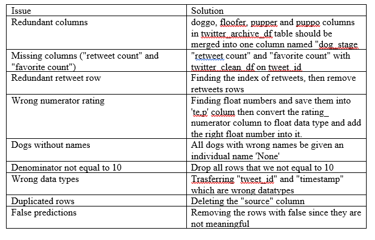

#### Storing Data

I saved the gathered, assessed, and cleaned master dataset to a CSV file named "twitter_archive_master.csv".